# Part_II_slide_deck slides

## Dataset Overview

This dataset contains loan information of about 113,937 rows with 81 variables on each loan, including loan amount, borrower rate (or interest rate), current loan status, borrower income, and many others.

I am looking forward to investigate the following questions

- What factors affect a loan’s outcome status?
- What affects the borrower’s APR or interest rate?
- Are there differences between loans depending on how large the original loan amount was?

### LoanOriginalAmount Vs MonthlyLoanPayme

> The correlation between LoanOriginalAmount and MonthlyLoanPayment is positive with some outliears.

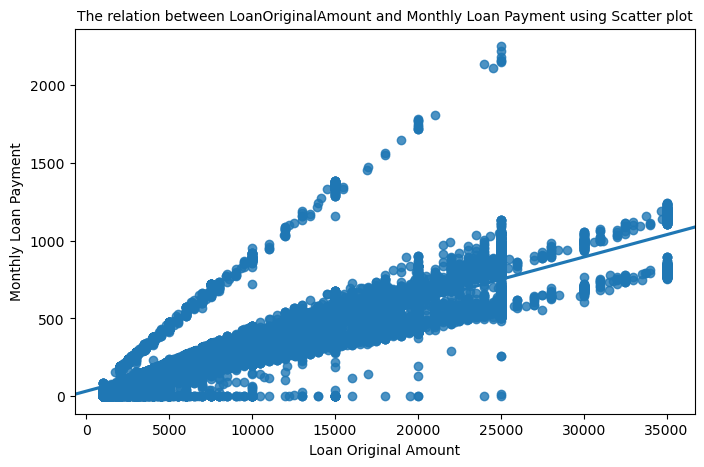

### LoanOriginalAmount Vs BorrowerAPR

> As we can see from the lone original amout and borrower APR relation the more darkesst place is on the region 0.35 to 0.40

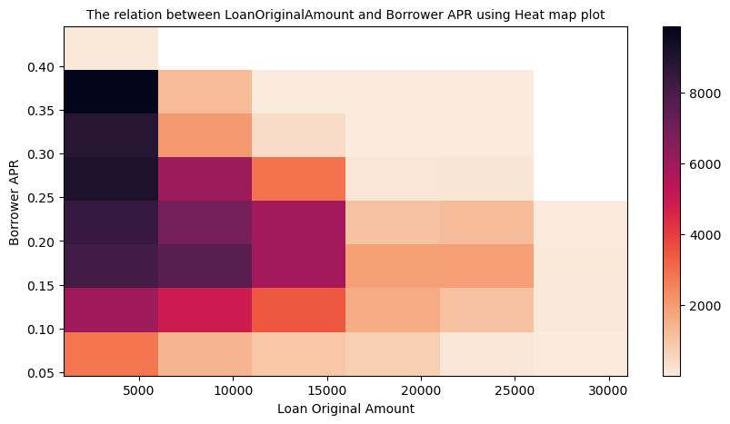

## MonthlyLoanPayment Vs Borrower Rate

> As can be seen, the monthly loan payment has a negative association with the borrower's rate, which means that as the monthly loan payment rises, the borrower's rate decreases. As a result, borrowers who make large monthly loan payments pay less interest, which, in my opinion, is a marketing ploy that enables borrowers who make large monthly payments to take out larger loans.

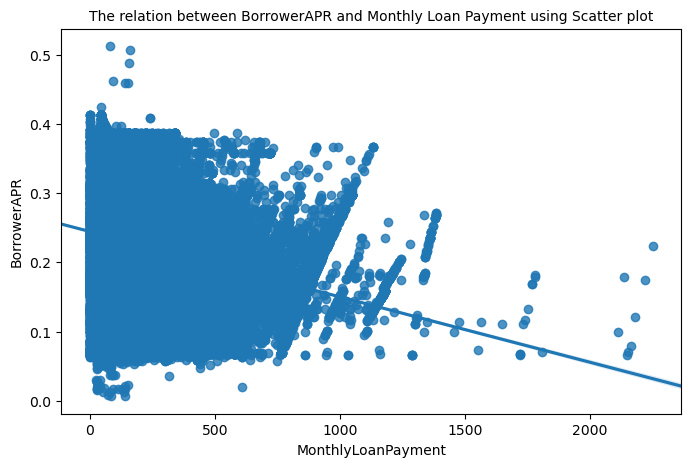

## LoanStatus Vs Borrower Rate

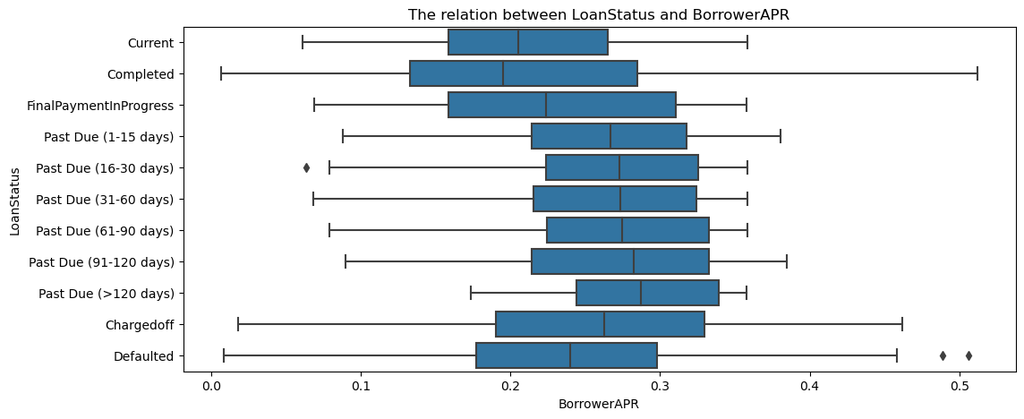

## Borrower rate Vs EmploymentStatus over time

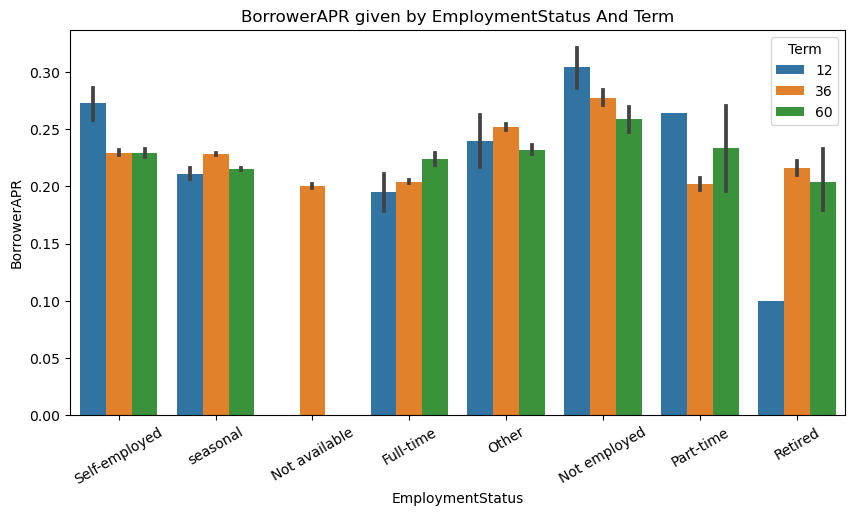